# 네이버 웹툰 스크래핑핑 및 분석

조민재

2020년 12월 13일

# 시작 전 라이브러리 불러오기 및 상수 정의

```r
library(httr)
library(rvest)
library(RSelenium)
library(seleniumPipes)
library(tidyverse)
library(wdman)

clean_text <- function(arg_text){
  arg_text <- gsub("\n", "", arg_text)
  arg_text <- gsub("\t", "", arg_text)
  arg_text <- trimws(arg_text)
  return(arg_text)
}

cDrv <- chrome()
```

```
## checking chromedriver versions:
```

```
## BEGIN: PREDOWNLOAD
```

```
## BEGIN: DOWNLOAD
```

```
## BEGIN: POSTDOWNLOAD
```

```r
eCaps <- list(chromeOptions = list(
  args = c('--headless', '--disable-gpu', '--window-size=1280,800')
))

remD <- remoteDriver(port = 4445L, browserName = "chrome", extraCapabilities = eCaps) # 포트번호 입력, 사용할 브라우저
remD$open() # 서버에 연결
```

[output not shown]

[output cut: 8 more lines]

[output not shown]

```r
# 변수
main_url <- "https://comic.naver.com/webtoon/weekday.nhn"
list_url <- "https://comic.naver.com/webtoon/list.nhn"
webtoon_url <- "https://comic.naver.com/webtoon/detail.nhn"
comment_url <- "https://comic.naver.com/comment/comment.nhn"
week_url <- "https://comic.naver.com/webtoon/weekdayList.nhn"
week_set <- c("mon", "tue", "wed", "thu", "fri", "sat", "sun") # 요일
```

# 네이버 웹툰 스크래핑

## 웹툰 기본 정보 가져오기

```r
# # 웹툰 정보 담을 df
# info_df <- tibble(
#   id <- c(),
#   title <- c(),
#   cartoonist <- c(),
#   genre <- c(),
#   last_episode <- c(),
#   week_rank <- c(),
#   week <- c(),
#   star_point <- c()
# )
# colnames(info_df) <- c("id", "title", "cartoonist", "genre", "last_episode", "week_rank", "week", "star_point")
#
# title_source <- GET(main_url) %>%
#   read_html()
#
# # 웹툰 메인사이트
# title_ids <- title_source %>%
#   html_nodes(".title") %>%
#   html_attrs()
#
# cnt_week <- 0 # 요일 구분
#
# ## 웹툰 정보 크롤링
# for(i_id in 1:length(title_ids)){ #
#   # 웹툰별 식별 id 가져오기
#   title_id <- title_ids[[i_id]][1]
#   title_id <- substr(title_id, 27, gregexpr("&weekday", title_id)[[1]] - 1) # /webtoon/list.nhn?titleId= 여기까지의 길이가 26이기에 여기에 1을 더한 값 부터, 그리고 &weekday가 포함된 인덱스까지에서 -1 까지의 문자열을 긁어오면 titleId 와 같은 값이 됨.
#   title_id <- title_id[[1]]
#
#   # 웹툰별 인기 순위 파악
#   title_rank <- title_ids[[i_id]][2]
#   title_rank <- substr(title_rank, 31, gregexpr("')", title_rank)[[1]] - 1)
#   title_rank <- title_rank[[1]]
#
#   # 요일
#   #print(paste0("id = ", i_id)) # 에러 테스트용
#   if(title_rank == "1"){
#     cnt_week <- cnt_week + 1
#   }
#   week <- week_set[[cnt_week]]
#
#   # 웹툰 리스트 화면
#   list_source <- GET(list_url,
#                      query=list(titleId=title_id)) %>%
#     read_html()
#
#   # 작가 파악
#   cartoonist <- list_source %>%
#     html_nodes(".wrt_nm") %>%
#     html_text()
#   cartoonist <- clean_text(cartoonist) # 전처리 필요
#
#   # 제목 파악
#   webtoon_title <- list_source %>%
#     html_nodes("h2") %>%
#     html_text()
#   webtoon_title <- clean_text(webtoon_title[[2]])
#   webtoon_title <- gsub(cartoonist, "", webtoon_title)
#
#   # 장르 파악
#   genre <- list_source %>%
#     html_nodes(".genre") %>%
#     html_text()
#
#   # 총 별점 파악
#   week_source <- GET(week_url, query=list(week=week)) %>%
#     read_html()
#
#   star_points <- week_source %>%
#     html_nodes(".rating_type strong") %>%
#     html_text
#   star_point <- star_points[[as.integer(title_rank)]]
#
#
#   # 마지막화 파악
#   last_episode <- list_source %>%
#     html_nodes(".v2+ tr a") %>%
#     html_attrs()
#
#   if(!is_empty(last_episode)){
#     last_episode <- last_episode[[1]]["onclick"]
#     last_episode <- last_episode %>%
#       substr(35, gregexpr(")",  last_episode)[[1]][[1]] -2) %>%
#       as.integer()
#   }else{
#     last_episode <- 0
#   }
#
#   # df에 넣기
#   info_df <- add_row(info_df, id = title_id, title = webtoon_title, cartoonist = cartoonist, genre = genre, last_episode = last_episode, week_rank = title_rank, week = week, star_point = star_point)
# }
# remD$close()
# cDrv$stop()
#
# write.csv(info_df, file="info_df.csv")
```

## 매 화당 평가 가져오기

문서로 제작하는데 시간이 너무 오래 걸리는 관계로 주석으로 처리한 점 양해부탁드립니다. 스크래핑 결과물은 evaluate_df.csv 파일에 저장됩니다.

```r
# # 평점 및 좋아요 참여자 담을 df
# evaluate_df <- tibble(
#   id <- c(),
#   episode <- c(),
#   starpoint <- c(),
#   participant <- c(),
#   heart <- c()
# )
# colnames(evaluate_df) <- c("id",  "episode",  "starpoint",  "participant",  "heart")
#
# remD <- remoteDriver(port = 4445L, browserName = "chrome", extraCapabilities = eCaps) # 포트번호 입력, 사용할 브라우저
# remD$open() # 서버에 연결
#
# title_ids <- info_df$id
# for(i_id in 1:length(title_ids)){ #
# # 마지막화
# print(paste0("id = ", i_id))
# title_id <- title_ids[[i_id]]
# last_episode <- info_df$last_episode[i_id]
#
# # 첫화부터 마지막 화까지 for문으로 돌음.
# for(i in 1:last_episode){
# print(paste0("episode : ", i))
# # 웹툰 화면
#
# remD$navigate(paste0(webtoon_url, "?titleId=", title_id,"&no=",i))
# webtoon_source <- remD$getPageSource()[[1]] %>%
# read_html()
#
# # 별점
# webtoon_star <- webtoon_source %>%
# html_nodes("#topPointTotalNumber strong") %>%
# html_text()
#
# # 별점 참여자
# webtoon_participate <- webtoon_source %>%
# html_nodes("#topTotalStarPoint .pointTotalPerson em") %>%
# html_text()
#
# # 하트 수
# webtoon_heart <- webtoon_source %>%
# html_nodes(".u_cnt") %>%
# html_text()
#
# evaluate_df <- add_row(evaluate_df, id = title_id, episode = i, starpoint = webtoon_star, participant = webtoon_participate, heart = webtoon_heart)
# }
# }
#
# remD$close()
# cDrv$stop()
#
# write.csv(evaluate_df, file="evaluate_df.csv")
```

# 분석

## 데이터 수집을 위한 준비.

```r
#install.packages("ggplot2")
#install.packages("tidyverse")
library(tidyverse)
library(ggplot2)
theme_set(theme_minimal())
```

```r
info_df <- read.csv("info_df.csv") # 웹툰 정보를 담은 데이터프레임 불러옴.
str(info_df)
```

```
## 'data.frame':    367 obs. of  9 variables:
##  $ X           : int  1 2 3 4 5 6 7 8 9 10 ...
##  $ id          : int  648419 758037 602910 654774 733074 754781 728750 749632 759940 739115 ...
##  $ title       : chr  "뷰티풀 군바리" "참교육" "윈드브레이커" "소녀의 세계" ...
##  $ cartoonist  : chr  "설이 / 윤성원" "채용택 / 한가람" "조용석" "모랑지" ...
##  $ genre       : chr  "스토리, 드라마" "스토리, 액션" "스토리, 스포츠" "스토리, 드라마" ...
##  $ last_episode: int  274 7 341 250 67 9 83 24 4 46 ...
##  $ week_rank   : int  1 2 3 4 5 6 7 8 9 10 ...
##  $ week        : chr  "mon" "mon" "mon" "mon" ...
##  $ star_point  : num  9.82 9.61 9.87 9.97 9.87 8.41 9.97 9.92 8.05 9.98 ...
```

```r
info_df$week_rank <- as.integer(info_df$week_rank) # 주 순위 정수형으로 변경
info_df$week <- as.factor(info_df$week) # 연재 요일 팩터형으로 변경
```

## 장르 비율 분석

### 서사 방식(스토리, 에피소드, 옴니버스) 포함

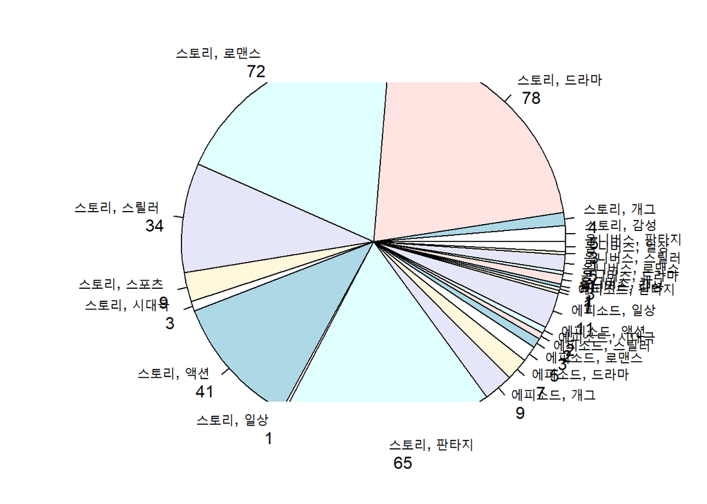

```r
all_genre <- table(info_df$genre)
label <- paste(names(all_genre), "\n", all_genre)

pie(all_genre, labels=label, radius=1.3)
```

### 서사 방식(스토리, 에피소드, 옴니버스) 비율

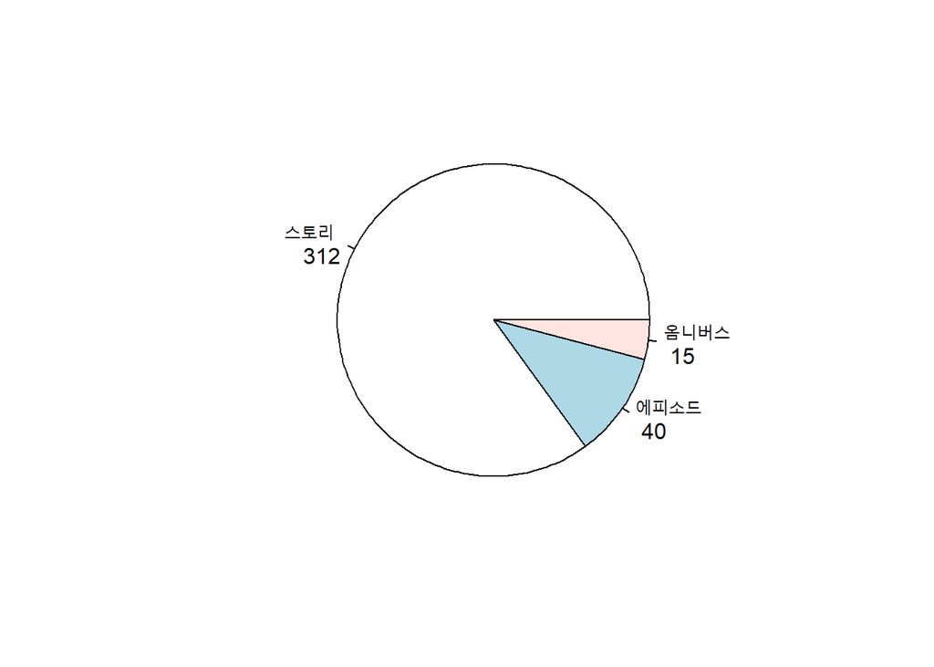

```r
split_genre_narrative <-  info_df$genre %>%
  strsplit(split=",")

narrative_method <- c()
for(i in 1:length(split_genre_narrative)){
  narrative_method <- append(narrative_method, split_genre_narrative[[i]][1])
}
narrative_method <- table(narrative_method)

label <- paste(names(narrative_method), "\n", narrative_method)
pie(narrative_method, labels=label, radius=0.8)
```

### 서사 방식(스토리, 에피소드, 옴니버스) 미포함 장르 비율

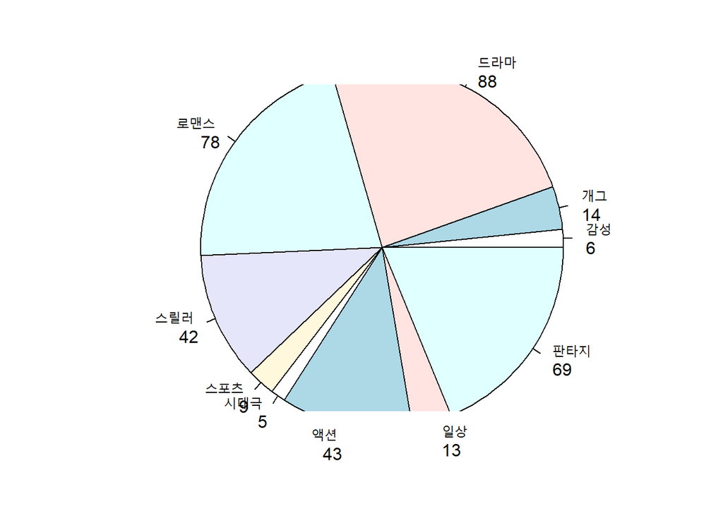

```r
genre <- c()
for(i in 1:length(split_genre_narrative)){
  genre <- append(genre, split_genre_narrative[[i]][2])
}
genre <- table(genre)

label <- paste(names(genre), "\n", genre)
pie(genre, labels=label, radius=1.2)
```

### 인기 많은 웹툰 서사 방식 스토리 웹툰이 옴니버스나 에피소드 웹툰보다 인기가 많다.

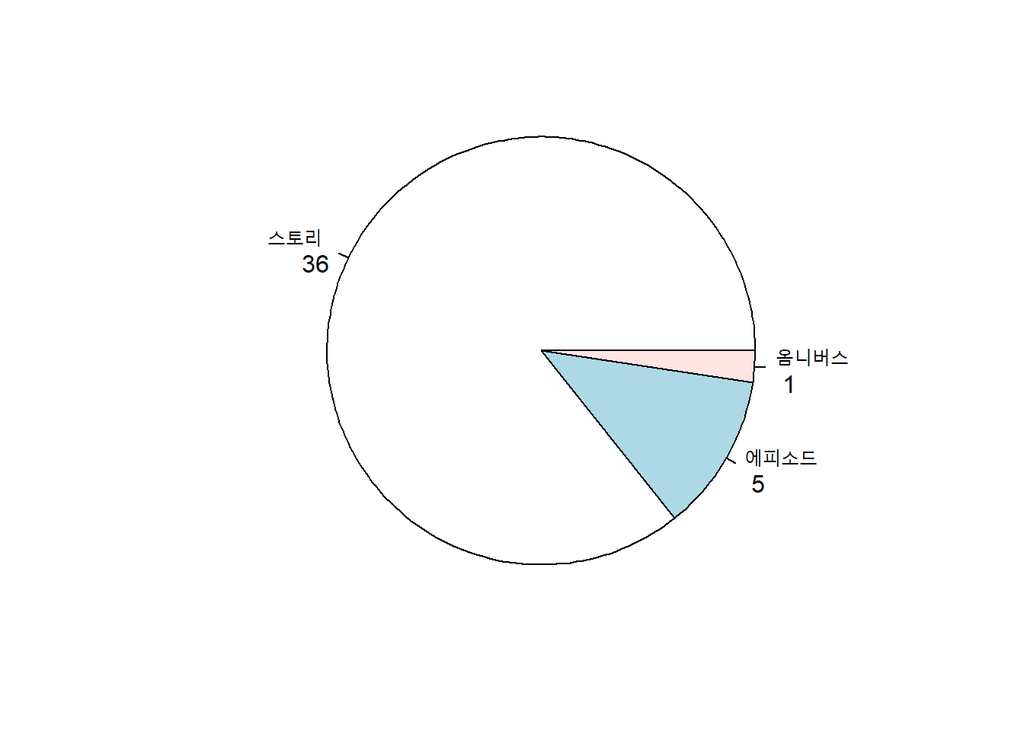

```r
hot_toon <- info_df %>%
  subset(week_rank <= 6) # 각 주별 순위 6위 이내만 추출

split_genre_narrative <-  hot_toon$genre %>%
  strsplit(split=",")

narrative_method <- c()
for(i in 1:length(split_genre_narrative)){
  narrative_method <- append(narrative_method, split_genre_narrative[[i]][1])
}
narrative_method <- table(narrative_method)

label <- paste(names(narrative_method), "\n", narrative_method)
pie(narrative_method, labels=label, radius=1.0)
```

### 인기 많은 웹툰 장르(서사 방식 미포함)

액션 장르가 전체 비율에 비해 인기가 많다. 감성 장르, 시대극 장르는 인기 6위 항목에 포함되지 못한다.

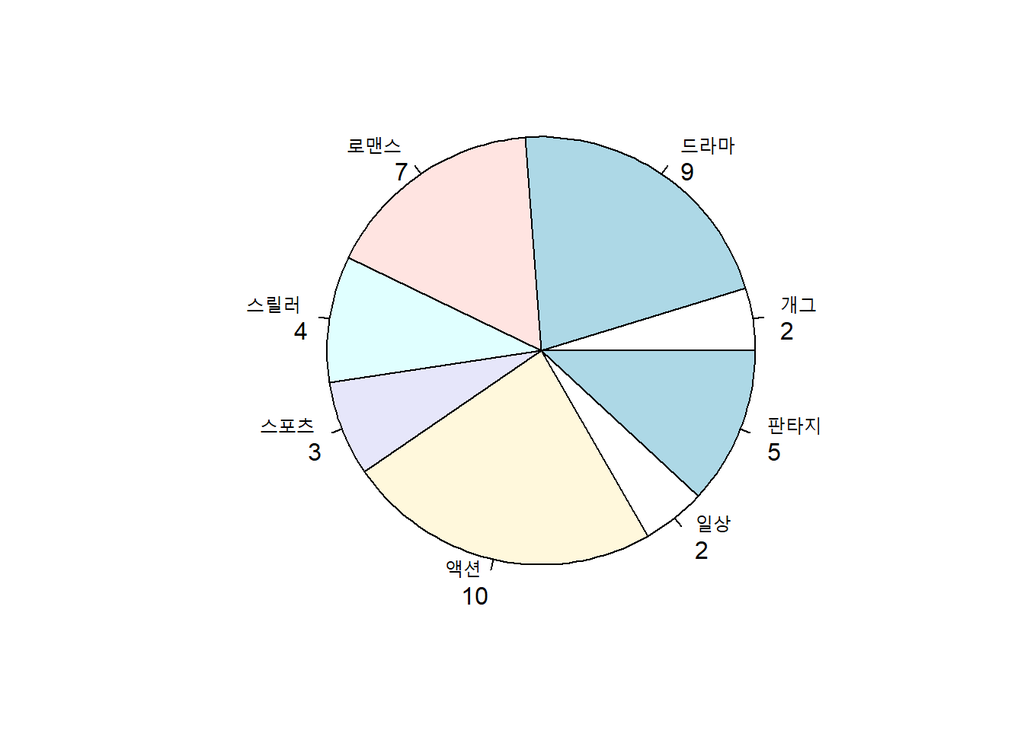

```r
genre <- c()
for(i in 1:length(split_genre_narrative)){
  genre <- append(genre, split_genre_narrative[[i]][2])
}
genre <- table(genre)

label <- paste(names(genre), "\n", genre)
pie(genre, labels=label, radius=1.0)
```

## 웹툰 시작에 따른 에피소드 별점 및 별점 참여 수 변화 추이

모든 웹툰을 스크래핑하는데 너무 많은 시간이 걸리기 때문에 월요일, 화요일 연재 웹툰만 사용하여 분석함. ### 웹툰 연재 시기에 따른 에피소드 별점 변화 추이 그래프 분석 결과 대다수의 웹툰들이 높은 별점을 유지함. 장기 웹툰 중 잠시 별점이 내려가는 웹툰들도 있으나 다시 높은 점수로 회복함. 이러한 웹툰들은 대체로 초반에 높은 별점을 받으며 시작함. 그래서 평균 높은 별점을 가짐. 초반에 높은 별점을 받지 못한 웹툰들은 계속 별점이 떨어지는 경우가 많음. 그 결과 전체 별점이 낮아짐.

```r
evaluate_df <- read.csv("evaluate_df.csv")
str(evaluate_df)
```

```
## 'data.frame':    9563 obs. of  6 variables:
##  $ X          : int  1 2 3 4 5 6 7 8 9 10 ...
##  $ id         : int  648419 648419 648419 648419 648419 648419 648419 648419 648419 648419 ...
##  $ episode    : int  1 2 1 2 3 4 5 6 1 2 ...
##  $ starpoint  : num  9.54 9.54 9.54 9.54 9.66 9.63 9.75 9.77 9.54 9.54 ...
##  $ participant: int  71479 62830 71479 62830 51387 51472 48456 45429 71479 62830 ...
##  $ heart      : chr  "43,565" "43,165" "43,565" "43,165" ...
```

```r
evaluate_df$heart <- gsub(",", "", evaluate_df$heart) %>%
  as.integer()
```

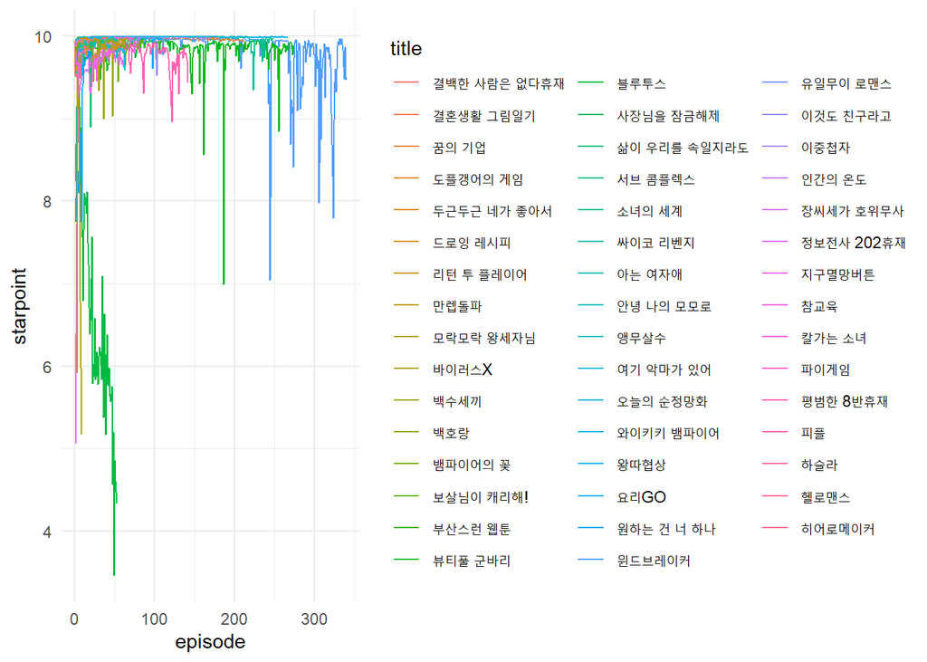

```r
temp_info_df <- info_df %>%
  select(id, week, title, )

evaluate_df <- left_join(evaluate_df, temp_info_df, by="id")

mon_df <- evaluate_df %>%
  subset(week == "mon") %>%
  group_by(id)
mon_df$id <- as.factor(mon_df$id)

tue_df <- evaluate_df %>%
  subset(week == "tue") %>%
  group_by(id)

#length(table(mon_df$id))

# 월요 웹툰
mon_g <- ggplot(mon_df, aes(x=episode, y=starpoint, group=id, colour = title), show.legend = FALSE)
mon_g <- mon_g + geom_line()
#mon_g <- mon_g + facet_wrap(~ id)
mon_g
```

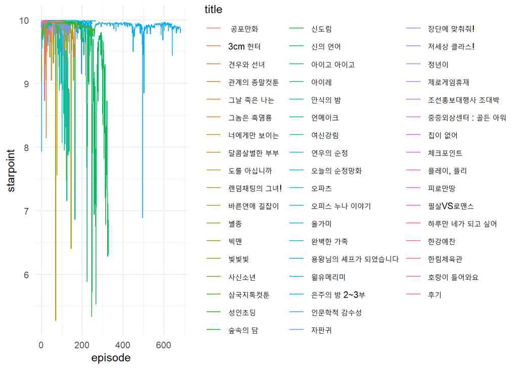

```r
# 화요 웹툰
tue_g <- ggplot(tue_df, aes(x=episode, y=starpoint, group=id, colour = title), show.legend = FALSE)
tue_g <- tue_g +geom_line()
#tue_g <- tue_g + facet_wrap(~ id)
tue_g
```

```r
mon_nojam <- info_df %>%
  subset(week == "mon") %>%
  subset(star_point < 9.0)

mon_nojam$title
```

```
## [1] "바이러스X"         "만렙돌파"          "원하는 건 너 하나"
## [4] "블루투스"
```

```r
tue_nojam <-  info_df %>%
  subset(week == "tue") %>%
  subset(star_point < 9.0)
tue_nojam
```

```
## [1] X            id           title        cartoonist   genre
## [6] last_episode week_rank    week         star_point
## <0 rows> (or 0-length row.names)
```

### 웹툰 연재 시기에 따른 에피소드 별점 리뷰 참여 수 변화 추이

아래의 그래프를 보면 뒤 에피소드로 갈 수록 별점을 평가하는 사람이 적어진다. 조회수 데이터를 스크래핑 해오지 못해 정확히 알 수는 없으나, 2가지 경우로 추측된다. 첫째, 사람들이 최신 화까지 챙겨보지 않는 경우로 볼 수 있다. 둘째, 웹툰의 특성상 몰입하여 보다가 별점 평가하는 것을 까먹는 사람들의 경향으로 볼 수 있다.

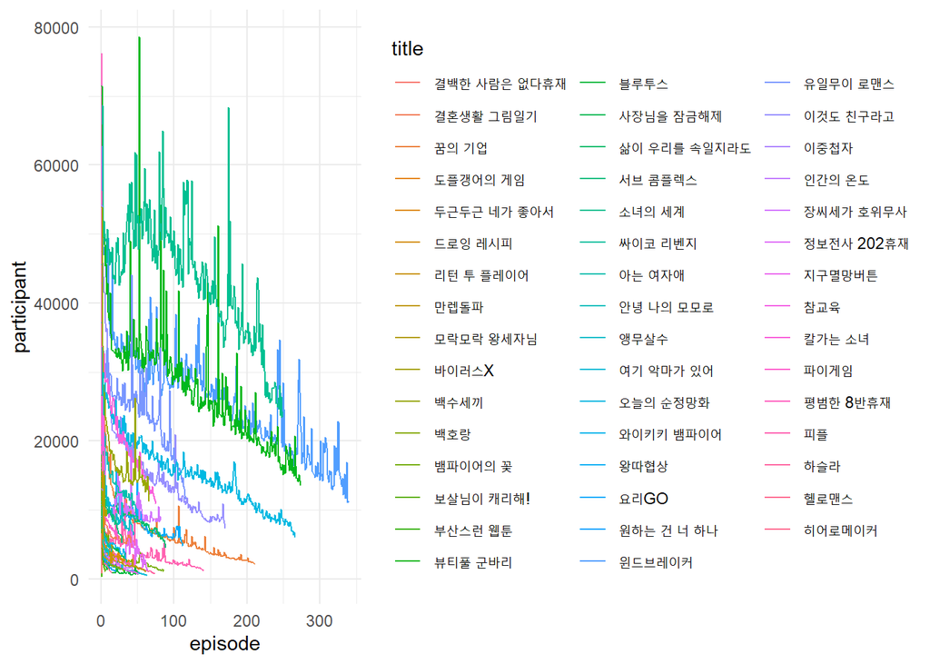

```r
# 월요 웹툰
mon_g <- ggplot(mon_df, aes(x=episode, y=participant, group=id, colour = title), show.legend = FALSE)
mon_g <- mon_g + geom_line()
#mon_g <- mon_g + facet_wrap(~ id)
mon_g
```

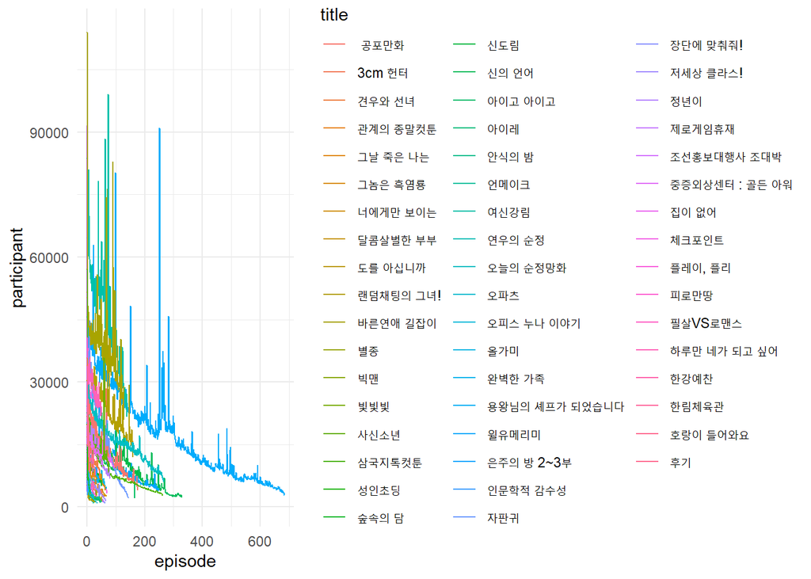

```r
# 화요 웹툰
tue_g <- ggplot(tue_df, aes(x=episode, y=participant, group=id, colour = title), show.legend = FALSE)
tue_g <- tue_g +geom_line()
#tue_g <- tue_g + facet_wrap(~ id)
tue_g
```

## 별점이 낮은 만화는 첫화부터 댓글 반응이 안 좋은가? 그리고 그 댓글은 무슨 내용인가?

### 월요일 웹툰 중 별점 낮은 웹툰 1화의 댓글 스크래핑

```r
cold_toon <- mon_nojam

### 댓글 스크래핑
# 댓글 담을 df
comment_df <- tibble(
  id <- c(),
  episode <- c(),
  amount_comments <- c(),
  episode_comments <- c(),
  episode_user <- c(),
  comments_good <- c()
)
colnames(comment_df) <- c("id", "episode", "amount_comments", "episode_comments", "episode_user", "comments_good")


cDrv <- chrome()
```

```
## checking chromedriver versions:
```

```
## BEGIN: PREDOWNLOAD
```

```
## BEGIN: DOWNLOAD
```

```
## BEGIN: POSTDOWNLOAD
```

```r
eCaps <- list(chromeOptions = list(
  args = c('--headless', '--disable-gpu', '--window-size=1280,800')
))

remD <- remoteDriver(port = 4445L, browserName = "chrome", extraCapabilities = eCaps) # 포트번호 입력, 사용할 브라우저
remD$open() # 서버에 연결
```

[output not shown]

[output cut: 8 more lines]

[output not shown]

```r
cold_toon_ids <- rownames(table(cold_toon$id))

for(i_id in 1:length(cold_toon_ids)){
  #print(paste0("id = ", i_id))
  print(cold_toon_ids[[i_id]])
  title_id <- cold_toon_ids[[i_id]]
  # 웹툰 리스트 화면
  list_source <- GET(list_url,
                     query=list(titleId=title_id)) %>%
    read_html()

  remD$navigate(paste0(comment_url, "?titleId=", title_id, "&no=",1))
  episode_comment_source <- remD$getPageSource()[[1]] %>%
    read_html()

  temp_amount_comments <- episode_comment_source %>%
    html_nodes(".u_cbox_count") %>%
    html_text()

  temp_episode_comments <- episode_comment_source %>%
    html_nodes(".u_cbox_contents") %>%
    html_text()

  temp_episode_user <- episode_comment_source %>%
    html_nodes(".u_cbox_nick") %>%
    html_text()

  temp_comments_good <- episode_comment_source %>%
    html_nodes(".u_cbox_cnt_recomm") %>%
    html_text()

  comment_df <- add_row(comment_df, id = title_id, episode = i, amount_comments = temp_amount_comments, episode_comments = temp_episode_comments, episode_user = temp_episode_user, comments_good = temp_comments_good)
  #
}
```

```
## [1] "737378"
## [1] "752530"
## [1] "754781"
## [1] "759940"
```

```r
### 댓글 스크래핑 끝
write.csv(comment_df, file="comment_df.csv")
```

```r
#install.packages("rJava")
# #install.packages("memoise")
# #install.packages("multiinguer")
# #install.packages(c('stringr', 'hash', 'tau', 'Sejong', 'RSQLite', 'devtools'), type = "binary")
# #install.packages("KoNLP")
# #install.packages("remotes")
# #remotes::install_github('haven-jeon/KoNLP', upgrade = "never", INSTALL_opts=c("--no-multiarch"), force = TRUE)
# #install.packages("wordcloud2")
#
# library("KoNLP")
# library(wordcloud2)
#
# useNIADic()
#
# text_ <- extractNoun(comment_df$episode_comments)
#
# extract_text <- c()
#
# for(i in 1:length(text_)){
#   extract_text <- append(extract_text, text_[[i]])
# }
#
# modif_text <- sort(table(extract_text), decreasing = TRUE)
#
# wordcloud2(modif_text)
```